# Project: Popular Movies Data Analysis

## By Ahmed ElBashary

- Introduction
- Data Wrangling
- Exploratory Data Analysis
- Conclusions

## Introduction

> This dataset contains more than 10,000 movies with their revenues, budgets, popularity, user ratings and many other aspects that we will use to figure out some patterns related to movies and find insights that will help us determine the measures of success for movies in the industry. This dataset was downloaded from Kaggle where it was collected from The Movie Database (TMDb)

> The questions that we think are best to imply to get sufficient insights out of this dataset are: **1) Which months have better revenue? Is it associated with holidays and seasons? 2) What are the properties that affect the proftability of the movies?**

```python
# Use this cell to set up import statements for all of the packages that you
#   plan to use.
import pandas as pd
import numpy as np
import matplotlib.pyplot as plt
import seaborn as sns

from pandas import Series
%matplotlib inline
```

## Data Wrangling

> In this section of the report, we will load in the data, check for cleanliness, and then trim and clean the dataset for analysis.

### General Properties

```python
#Loading the dataset and checking it
df = pd.read_csv('tmdb-movies.csv')
df.head()
```

|  | id | imdb_id | popularity | budget | revenue | original_title | cast | homepage | director | tagline | ... | overview | runtime | genres | production_companies | release_date | vote_count | vote_average | release_year | budget_adj | revenue_adj |
| --- | --- | --- | --- | --- | --- | --- | --- | --- | --- | --- | --- | --- | --- | --- | --- | --- | --- | --- | --- | --- | --- |
| 0 | 135397 | tt0369610 | 32.985763 | 150000000 | 1513528810 | Jurassic World | Chris Pratt\|Bryce Dallas Howard\|Irrfan Khan\|Vi... | http://www.jurassicworld.com/ | Colin Trevorrow | The park is open. | ... | Twenty-two years after the events of Jurassic ... | 124 | Action\|Adventure\|Science Fiction\|Thriller | Universal Studios\|Amblin Entertainment\|Legenda... | 6/9/15 | 5562 | 6.5 | 2015 | 1.379999e+08 | 1.392446e+09 |
| 1 | 76341 | tt1392190 | 28.419936 | 150000000 | 378436354 | Mad Max: Fury Road | Tom Hardy\|Charlize Theron\|Hugh Keays-Byrne\|Nic... | http://www.madmaxmovie.com/ | George Miller | What a Lovely Day. | ... | An apocalyptic story set in the furthest reach... | 120 | Action\|Adventure\|Science Fiction\|Thriller | Village Roadshow Pictures\|Kennedy Miller Produ... | 5/13/15 | 6185 | 7.1 | 2015 | 1.379999e+08 | 3.481613e+08 |
| 2 | 262500 | tt2908446 | 13.112507 | 110000000 | 295238201 | Insurgent | Shailene Woodley\|Theo James\|Kate Winslet\|Ansel... | http://www.thedivergentseries.movie/#insurgent | Robert Schwentke | One Choice Can Destroy You | ... | Beatrice Prior must confront her inner demons ... | 119 | Adventure\|Science Fiction\|Thriller | Summit Entertainment\|Mandeville Films\|Red Wago... | 3/18/15 | 2480 | 6.3 | 2015 | 1.012000e+08 | 2.716190e+08 |
| 3 | 140607 | tt2488496 | 11.173104 | 200000000 | 2068178225 | Star Wars: The Force Awakens | Harrison Ford\|Mark Hamill\|Carrie Fisher\|Adam D... | http://www.starwars.com/films/star-wars-episod... | J.J. Abrams | Every generation has a story. | ... | Thirty years after defeating the Galactic Empi... | 136 | Action\|Adventure\|Science Fiction\|Fantasy | Lucasfilm\|Truenorth Productions\|Bad Robot | 12/15/15 | 5292 | 7.5 | 2015 | 1.839999e+08 | 1.902723e+09 |
| 4 | 168259 | tt2820852 | 9.335014 | 190000000 | 1506249360 | Furious 7 | Vin Diesel\|Paul Walker\|Jason Statham\|Michelle ... | http://www.furious7.com/ | James Wan | Vengeance Hits Home | ... | Deckard Shaw seeks revenge against Dominic Tor... | 137 | Action\|Crime\|Thriller | Universal Pictures\|Original Film\|Media Rights ... | 4/1/15 | 2947 | 7.3 | 2015 | 1.747999e+08 | 1.385749e+09 |

5 rows × 21 columns

```python
df.shape
```

```
(10866, 21)
```

```python
df.describe()
```

|  | id | popularity | budget | revenue | runtime | vote_count | vote_average | release_year | budget_adj | revenue_adj |
| --- | --- | --- | --- | --- | --- | --- | --- | --- | --- | --- |
| count | 10866.000000 | 10866.000000 | 1.086600e+04 | 1.086600e+04 | 10866.000000 | 10866.000000 | 10866.000000 | 10866.000000 | 1.086600e+04 | 1.086600e+04 |
| mean | 66064.177434 | 0.646441 | 1.462570e+07 | 3.982332e+07 | 102.070863 | 217.389748 | 5.974922 | 2001.322658 | 1.755104e+07 | 5.136436e+07 |
| std | 92130.136561 | 1.000185 | 3.091321e+07 | 1.170035e+08 | 31.381405 | 575.619058 | 0.935142 | 12.812941 | 3.430616e+07 | 1.446325e+08 |
| min | 5.000000 | 0.000065 | 0.000000e+00 | 0.000000e+00 | 0.000000 | 10.000000 | 1.500000 | 1960.000000 | 0.000000e+00 | 0.000000e+00 |
| 25% | 10596.250000 | 0.207583 | 0.000000e+00 | 0.000000e+00 | 90.000000 | 17.000000 | 5.400000 | 1995.000000 | 0.000000e+00 | 0.000000e+00 |
| 50% | 20669.000000 | 0.383856 | 0.000000e+00 | 0.000000e+00 | 99.000000 | 38.000000 | 6.000000 | 2006.000000 | 0.000000e+00 | 0.000000e+00 |
| 75% | 75610.000000 | 0.713817 | 1.500000e+07 | 2.400000e+07 | 111.000000 | 145.750000 | 6.600000 | 2011.000000 | 2.085325e+07 | 3.369710e+07 |
| max | 417859.000000 | 32.985763 | 4.250000e+08 | 2.781506e+09 | 900.000000 | 9767.000000 | 9.200000 | 2015.000000 | 4.250000e+08 | 2.827124e+09 |

> As you can see there are more than half the dataset revenues and budgets with zero and this means that this data is missing so I think we should drop them as they will affect the analysis negatively.

> We also have to check the runtimes which is equal to zero because this is considered missing value.

```python
df.describe(include='all')
```

|  | id | imdb_id | popularity | budget | revenue | original_title | cast | homepage | director | tagline | ... | overview | runtime | genres | production_companies | release_date | vote_count | vote_average | release_year | budget_adj | revenue_adj |
| --- | --- | --- | --- | --- | --- | --- | --- | --- | --- | --- | --- | --- | --- | --- | --- | --- | --- | --- | --- | --- | --- |
| count | 10866.000000 | 10856 | 10866.000000 | 1.086600e+04 | 1.086600e+04 | 10866 | 10790 | 2936 | 10822 | 8042 | ... | 10862 | 10866.000000 | 10843 | 9836 | 10866 | 10866.000000 | 10866.000000 | 10866.000000 | 1.086600e+04 | 1.086600e+04 |
| unique | NaN | 10855 | NaN | NaN | NaN | 10571 | 10719 | 2896 | 5067 | 7997 | ... | 10847 | NaN | 2039 | 7445 | 5909 | NaN | NaN | NaN | NaN | NaN |
| top | NaN | tt0411951 | NaN | NaN | NaN | Hamlet | Louis C.K. | http://www.thehungergames.movie/ | Woody Allen | Based on a true story. | ... | No overview found. | NaN | Drama | Paramount Pictures | 1/1/09 | NaN | NaN | NaN | NaN | NaN |
| freq | NaN | 2 | NaN | NaN | NaN | 4 | 6 | 4 | 45 | 5 | ... | 13 | NaN | 712 | 156 | 28 | NaN | NaN | NaN | NaN | NaN |
| mean | 66064.177434 | NaN | 0.646441 | 1.462570e+07 | 3.982332e+07 | NaN | NaN | NaN | NaN | NaN | ... | NaN | 102.070863 | NaN | NaN | NaN | 217.389748 | 5.974922 | 2001.322658 | 1.755104e+07 | 5.136436e+07 |
| std | 92130.136561 | NaN | 1.000185 | 3.091321e+07 | 1.170035e+08 | NaN | NaN | NaN | NaN | NaN | ... | NaN | 31.381405 | NaN | NaN | NaN | 575.619058 | 0.935142 | 12.812941 | 3.430616e+07 | 1.446325e+08 |
| min | 5.000000 | NaN | 0.000065 | 0.000000e+00 | 0.000000e+00 | NaN | NaN | NaN | NaN | NaN | ... | NaN | 0.000000 | NaN | NaN | NaN | 10.000000 | 1.500000 | 1960.000000 | 0.000000e+00 | 0.000000e+00 |
| 25% | 10596.250000 | NaN | 0.207583 | 0.000000e+00 | 0.000000e+00 | NaN | NaN | NaN | NaN | NaN | ... | NaN | 90.000000 | NaN | NaN | NaN | 17.000000 | 5.400000 | 1995.000000 | 0.000000e+00 | 0.000000e+00 |
| 50% | 20669.000000 | NaN | 0.383856 | 0.000000e+00 | 0.000000e+00 | NaN | NaN | NaN | NaN | NaN | ... | NaN | 99.000000 | NaN | NaN | NaN | 38.000000 | 6.000000 | 2006.000000 | 0.000000e+00 | 0.000000e+00 |
| 75% | 75610.000000 | NaN | 0.713817 | 1.500000e+07 | 2.400000e+07 | NaN | NaN | NaN | NaN | NaN | ... | NaN | 111.000000 | NaN | NaN | NaN | 145.750000 | 6.600000 | 2011.000000 | 2.085325e+07 | 3.369710e+07 |
| max | 417859.000000 | NaN | 32.985763 | 4.250000e+08 | 2.781506e+09 | NaN | NaN | NaN | NaN | NaN | ... | NaN | 900.000000 | NaN | NaN | NaN | 9767.000000 | 9.200000 | 2015.000000 | 4.250000e+08 | 2.827124e+09 |

11 rows × 21 columns

```python
df.columns
```

```
Index(['id', 'imdb_id', 'popularity', 'budget', 'revenue', 'original_title',
       'cast', 'homepage', 'director', 'tagline', 'keywords', 'overview',
       'runtime', 'genres', 'production_companies', 'release_date',
       'vote_count', 'vote_average', 'release_year', 'budget_adj',
       'revenue_adj'],
      dtype='object')
```

```python
df.info()
```

```
<class 'pandas.core.frame.DataFrame'>
RangeIndex: 10866 entries, 0 to 10865
Data columns (total 21 columns):
id                      10866 non-null int64
imdb_id                 10856 non-null object
popularity              10866 non-null float64
budget                  10866 non-null int64
revenue                 10866 non-null int64
original_title          10866 non-null object
cast                    10790 non-null object
homepage                2936 non-null object
director                10822 non-null object
tagline                 8042 non-null object
keywords                9373 non-null object
overview                10862 non-null object
runtime                 10866 non-null int64
genres                  10843 non-null object
production_companies    9836 non-null object
release_date            10866 non-null object
vote_count              10866 non-null int64
vote_average            10866 non-null float64
release_year            10866 non-null int64
budget_adj              10866 non-null float64
revenue_adj             10866 non-null float64
dtypes: float64(4), int64(6), object(11)
memory usage: 1.7+ MB
```

> The id and imdb id columns are too specific to the website which we will not use in the analysis. Also, the name of the movie is not relevant as it is too specific to the movie itself.

> The homepage, tagline, keywords and overview are information that is not relevant to the questions that we are answering; therefore, we will drop them.

> Moreover, the release date is an object which we will convert to datetime for easier analysis.

### Data Cleaning

First, we start with dropping the columns

```python
# Drop columns that will not be useful for our analysis
df.drop(['id','imdb_id','homepage','tagline','keywords','overview'], axis = 1, inplace = True)
```

```python
# Checking dropped columns
df.info()
```

```
<class 'pandas.core.frame.DataFrame'>
RangeIndex: 10866 entries, 0 to 10865
Data columns (total 15 columns):
popularity              10866 non-null float64
budget                  10866 non-null int64
revenue                 10866 non-null int64
original_title          10866 non-null object
cast                    10790 non-null object
director                10822 non-null object
runtime                 10866 non-null int64
genres                  10843 non-null object
production_companies    9836 non-null object
release_date            10866 non-null object
vote_count              10866 non-null int64
vote_average            10866 non-null float64
release_year            10866 non-null int64
budget_adj              10866 non-null float64
revenue_adj             10866 non-null float64
dtypes: float64(4), int64(5), object(6)
memory usage: 1.2+ MB
```

Second, we drop duplicate rows (There was only 1 row to drop)

```python
# Find duplicates in dataset
df.duplicated().sum()
```

```
1
```

```python
# Drop them and check
df.drop_duplicates(inplace=True)
df.duplicated().sum()
```

```
0
```

Changing the date to datetime format

```python
df['release_date'] = pd.to_datetime(df['release_date'])
```

Checking the number of rows with zeros in revenue and budget and then dropping them

```python
df.drop(df[df['budget'] == df['budget'].min()].index, inplace = True)
```

```python
df.drop(df[df['revenue'] == df['revenue'].min()].index, inplace = True)
```

```python
df.info()
```

```
<class 'pandas.core.frame.DataFrame'>
Int64Index: 3854 entries, 0 to 10848
Data columns (total 15 columns):
popularity              3854 non-null float64
budget                  3854 non-null int64
revenue                 3854 non-null int64
original_title          3854 non-null object
cast                    3850 non-null object
director                3853 non-null object
runtime                 3854 non-null int64
genres                  3854 non-null object
production_companies    3808 non-null object
release_date            3854 non-null datetime64[ns]
vote_count              3854 non-null int64
vote_average            3854 non-null float64
release_year            3854 non-null int64
budget_adj              3854 non-null float64
revenue_adj             3854 non-null float64
dtypes: datetime64[ns](1), float64(4), int64(5), object(5)
memory usage: 481.8+ KB
```

```python
df.dropna(inplace=True)
```

```python
df.isnull().sum()
```

```
popularity              0
budget                  0
revenue                 0
original_title          0
cast                    0
director                0
runtime                 0
genres                  0
production_companies    0
release_date            0
vote_count              0
vote_average            0
release_year            0
budget_adj              0
revenue_adj             0
dtype: int64
```

```python
df.describe()
```

|  | popularity | budget | revenue | runtime | vote_count | vote_average | release_year | budget_adj | revenue_adj |
| --- | --- | --- | --- | --- | --- | --- | --- | --- | --- |
| count | 3805.000000 | 3.805000e+03 | 3.805000e+03 | 3805.000000 | 3805.000000 | 3805.000000 | 3805.000000 | 3.805000e+03 | 3.805000e+03 |
| mean | 1.203784 | 3.760800e+07 | 1.089734e+08 | 109.351117 | 534.159001 | 6.170565 | 2001.229172 | 4.471977e+07 | 1.387159e+08 |
| std | 1.480569 | 4.232179e+07 | 1.772976e+08 | 19.845678 | 883.757588 | 0.792437 | 11.329616 | 4.488697e+07 | 2.169973e+08 |
| min | 0.010335 | 1.000000e+00 | 2.000000e+00 | 15.000000 | 10.000000 | 2.200000 | 1960.000000 | 9.693980e-01 | 2.370705e+00 |
| 25% | 0.470651 | 1.000000e+07 | 1.433379e+07 | 96.000000 | 74.000000 | 5.700000 | 1995.000000 | 1.354637e+07 | 1.925371e+07 |
| 50% | 0.810805 | 2.500000e+07 | 4.621664e+07 | 106.000000 | 209.000000 | 6.200000 | 2004.000000 | 3.038360e+07 | 6.284688e+07 |
| 75% | 1.387163 | 5.000000e+07 | 1.260695e+08 | 119.000000 | 584.000000 | 6.700000 | 2010.000000 | 6.084153e+07 | 1.658054e+08 |
| max | 32.985763 | 4.250000e+08 | 2.781506e+09 | 338.000000 | 9767.000000 | 8.400000 | 2015.000000 | 4.250000e+08 | 2.827124e+09 |

```python
df.describe(include='all')
```

|  | popularity | budget | revenue | original_title | cast | director | runtime | genres | production_companies | release_date | vote_count | vote_average | release_year | budget_adj | revenue_adj |
| --- | --- | --- | --- | --- | --- | --- | --- | --- | --- | --- | --- | --- | --- | --- | --- |
| count | 3805.000000 | 3.805000e+03 | 3.805000e+03 | 3805 | 3805 | 3805 | 3805.000000 | 3805 | 3805 | 3805 | 3805.000000 | 3805.000000 | 3805.000000 | 3.805000e+03 | 3.805000e+03 |
| unique | NaN | NaN | NaN | 3760 | 3784 | 1683 | NaN | 1043 | 3005 | 2857 | NaN | NaN | NaN | NaN | NaN |
| top | NaN | NaN | NaN | Footloose | William Shatner\|Leonard Nimoy\|DeForest Kelley\|... | Steven Spielberg | NaN | Drama | Paramount Pictures | 2014-12-25 00:00:00 | NaN | NaN | NaN | NaN | NaN |
| freq | NaN | NaN | NaN | 2 | 5 | 27 | NaN | 243 | 77 | 7 | NaN | NaN | NaN | NaN | NaN |
| first | NaN | NaN | NaN | NaN | NaN | NaN | NaN | NaN | NaN | 1970-01-24 00:00:00 | NaN | NaN | NaN | NaN | NaN |
| last | NaN | NaN | NaN | NaN | NaN | NaN | NaN | NaN | NaN | 2069-12-12 00:00:00 | NaN | NaN | NaN | NaN | NaN |
| mean | 1.203784 | 3.760800e+07 | 1.089734e+08 | NaN | NaN | NaN | 109.351117 | NaN | NaN | NaN | 534.159001 | 6.170565 | 2001.229172 | 4.471977e+07 | 1.387159e+08 |
| std | 1.480569 | 4.232179e+07 | 1.772976e+08 | NaN | NaN | NaN | 19.845678 | NaN | NaN | NaN | 883.757588 | 0.792437 | 11.329616 | 4.488697e+07 | 2.169973e+08 |
| min | 0.010335 | 1.000000e+00 | 2.000000e+00 | NaN | NaN | NaN | 15.000000 | NaN | NaN | NaN | 10.000000 | 2.200000 | 1960.000000 | 9.693980e-01 | 2.370705e+00 |
| 25% | 0.470651 | 1.000000e+07 | 1.433379e+07 | NaN | NaN | NaN | 96.000000 | NaN | NaN | NaN | 74.000000 | 5.700000 | 1995.000000 | 1.354637e+07 | 1.925371e+07 |
| 50% | 0.810805 | 2.500000e+07 | 4.621664e+07 | NaN | NaN | NaN | 106.000000 | NaN | NaN | NaN | 209.000000 | 6.200000 | 2004.000000 | 3.038360e+07 | 6.284688e+07 |
| 75% | 1.387163 | 5.000000e+07 | 1.260695e+08 | NaN | NaN | NaN | 119.000000 | NaN | NaN | NaN | 584.000000 | 6.700000 | 2010.000000 | 6.084153e+07 | 1.658054e+08 |
| max | 32.985763 | 4.250000e+08 | 2.781506e+09 | NaN | NaN | NaN | 338.000000 | NaN | NaN | NaN | 9767.000000 | 8.400000 | 2015.000000 | 4.250000e+08 | 2.827124e+09 |

Now, as you can see the data looks so much cleaner with no null values. Also, the huge number of zero budget and revenue movies have been eliminated for better analysis and clearer insights.

### Here will find the profit for all the movies (Creating the dependent Variable)

```python
df['profit'] = df['revenue'] - df['budget']
```

## Exploratory Data Analysis

> This is where we will explore the data in order to answer the questions we stated at the beginning of this report

### 1. Which months have better revenue? Is it associated with holidays and seasons?

```python
# First, we need to make a column for months (Extracted from the released date column)
df['month'] = pd.DatetimeIndex(df['release_date']).month
df.head()
```

|  | popularity | budget | revenue | original_title | cast | director | runtime | genres | production_companies | release_date | vote_count | vote_average | release_year | budget_adj | revenue_adj | profit | month |
| --- | --- | --- | --- | --- | --- | --- | --- | --- | --- | --- | --- | --- | --- | --- | --- | --- | --- |
| 0 | 32.985763 | 150000000 | 1513528810 | Jurassic World | Chris Pratt\|Bryce Dallas Howard\|Irrfan Khan\|Vi... | Colin Trevorrow | 124 | Action\|Adventure\|Science Fiction\|Thriller | Universal Studios\|Amblin Entertainment\|Legenda... | 2015-06-09 | 5562 | 6.5 | 2015 | 1.379999e+08 | 1.392446e+09 | 1363528810 | 6 |
| 1 | 28.419936 | 150000000 | 378436354 | Mad Max: Fury Road | Tom Hardy\|Charlize Theron\|Hugh Keays-Byrne\|Nic... | George Miller | 120 | Action\|Adventure\|Science Fiction\|Thriller | Village Roadshow Pictures\|Kennedy Miller Produ... | 2015-05-13 | 6185 | 7.1 | 2015 | 1.379999e+08 | 3.481613e+08 | 228436354 | 5 |
| 2 | 13.112507 | 110000000 | 295238201 | Insurgent | Shailene Woodley\|Theo James\|Kate Winslet\|Ansel... | Robert Schwentke | 119 | Adventure\|Science Fiction\|Thriller | Summit Entertainment\|Mandeville Films\|Red Wago... | 2015-03-18 | 2480 | 6.3 | 2015 | 1.012000e+08 | 2.716190e+08 | 185238201 | 3 |
| 3 | 11.173104 | 200000000 | 2068178225 | Star Wars: The Force Awakens | Harrison Ford\|Mark Hamill\|Carrie Fisher\|Adam D... | J.J. Abrams | 136 | Action\|Adventure\|Science Fiction\|Fantasy | Lucasfilm\|Truenorth Productions\|Bad Robot | 2015-12-15 | 5292 | 7.5 | 2015 | 1.839999e+08 | 1.902723e+09 | 1868178225 | 12 |
| 4 | 9.335014 | 190000000 | 1506249360 | Furious 7 | Vin Diesel\|Paul Walker\|Jason Statham\|Michelle ... | James Wan | 137 | Action\|Crime\|Thriller | Universal Pictures\|Original Film\|Media Rights ... | 2015-04-01 | 2947 | 7.3 | 2015 | 1.747999e+08 | 1.385749e+09 | 1316249360 | 4 |

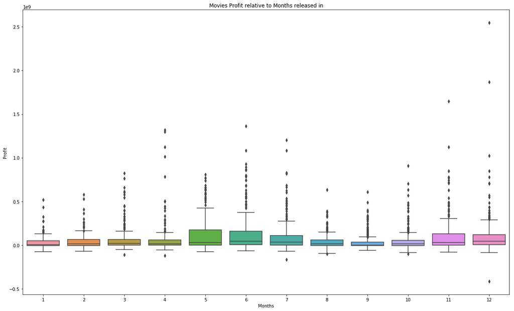

```python
# Plotting the box plots for each month to see which ones have the highest profit
fig, ax = plt.subplots(figsize=(20,12))

sns.boxplot(x='month', y='profit', data=df, ax=ax)
ax.set_xlabel('Months')
ax.set_ylabel('Profit')
ax.set_title('Movies Profit relative to Months released in');
```

### *As we can all see that it is relative to holidays as May and June are the highest which are both the beginning of summer days and also november and december are both relatiely higher than the rest of the year which are the winter holidays and Christmas time.*

### 2. What are the properties that affect the proftability of the movies?

```python
# Here we will investigate the trends of the top 250 profitable movies
df_top = df[['original_title','budget','vote_average','vote_count','popularity','genres','profit']].sort_values(by='profit', ascending = False).head(250)
df_top.head(20)
```

|  | original_title | budget | vote_average | vote_count | popularity | genres | profit |
| --- | --- | --- | --- | --- | --- | --- | --- |
| 1386 | Avatar | 237000000 | 7.1 | 8458 | 9.432768 | Action\|Adventure\|Fantasy\|Science Fiction | 2544505847 |
| 3 | Star Wars: The Force Awakens | 200000000 | 7.5 | 5292 | 11.173104 | Action\|Adventure\|Science Fiction\|Fantasy | 1868178225 |
| 5231 | Titanic | 200000000 | 7.3 | 4654 | 4.355219 | Drama\|Romance\|Thriller | 1645034188 |
| 0 | Jurassic World | 150000000 | 6.5 | 5562 | 32.985763 | Action\|Adventure\|Science Fiction\|Thriller | 1363528810 |
| 4 | Furious 7 | 190000000 | 7.3 | 2947 | 9.335014 | Action\|Crime\|Thriller | 1316249360 |
| 4361 | The Avengers | 220000000 | 7.3 | 8903 | 7.637767 | Science Fiction\|Action\|Adventure | 1299557910 |
| 3374 | Harry Potter and the Deathly Hallows: Part 2 | 125000000 | 7.7 | 3750 | 5.711315 | Adventure\|Family\|Fantasy | 1202817822 |
| 14 | Avengers: Age of Ultron | 280000000 | 7.4 | 4304 | 5.944927 | Action\|Adventure\|Science Fiction | 1125035767 |
| 5422 | Frozen | 150000000 | 7.5 | 3369 | 6.112766 | Animation\|Adventure\|Family | 1124219009 |
| 8094 | The Net | 22000000 | 5.6 | 201 | 1.136610 | Crime\|Drama\|Mystery\|Thriller\|Action | 1084279658 |
| 8 | Minions | 74000000 | 6.5 | 2893 | 7.404165 | Family\|Animation\|Adventure\|Comedy | 1082730962 |
| 4949 | The Lord of the Rings: The Return of the King | 94000000 | 7.9 | 5636 | 7.122455 | Adventure\|Fantasy\|Action | 1024888979 |
| 5425 | Iron Man 3 | 200000000 | 6.9 | 6882 | 4.946136 | Action\|Adventure\|Science Fiction | 1015439994 |
| 3522 | Transformers: Dark of the Moon | 195000000 | 6.1 | 2456 | 0.760503 | Action\|Science Fiction\|Adventure | 928746996 |
| 4365 | Skyfall | 200000000 | 6.8 | 6137 | 5.603587 | Action\|Adventure\|Thriller | 908561013 |
| 5434 | Despicable Me 2 | 76000000 | 7.0 | 3436 | 3.928789 | Animation\|Comedy\|Family | 894761885 |
| 6555 | Pirates of the Caribbean: Dead Man's Chest | 200000000 | 6.8 | 3181 | 4.205992 | Adventure\|Fantasy\|Action | 865659812 |
| 1930 | Toy Story 3 | 200000000 | 7.5 | 2924 | 2.711136 | Animation\|Family\|Comedy | 863171911 |
| 10223 | Jurassic Park | 63000000 | 7.4 | 3169 | 2.204926 | Adventure\|Science Fiction | 857100000 |
| 2634 | Harry Potter and the Philosopher's Stone | 125000000 | 7.2 | 4265 | 8.021423 | Adventure\|Fantasy\|Family | 851475550 |

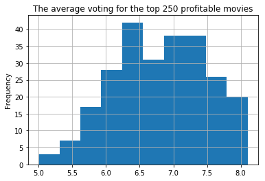

```python
df_top['vote_average'].plot(kind ='hist', grid=True, title='The average voting for the top 250 profitable movies');
```

### *This graph shows that one of the properties of a profitable movie is getting around 6.2 or more in the average rating of the movie by customers*

```python
# Creating a dummy df to split the genres to see their effect on profitability (For top 250 Movies)
df1 = df_top

split_g = df1['genres'].str.split('|').apply(Series, 1).stack() #splitting genres on the character '|'

split_g.index = split_g.index.droplevel(-1) # to line up with df's index
split_g.name = 'genres' # needs a name to join in df

del df1['genres'] # deleting the old genres column

df1.join(split_g) #joining the series to the df
```

|  | original_title | budget | vote_average | vote_count | popularity | profit | genres |
| --- | --- | --- | --- | --- | --- | --- | --- |
| 0 | Jurassic World | 150000000 | 6.5 | 5562 | 32.985763 | 1363528810 | Action |
| 0 | Jurassic World | 150000000 | 6.5 | 5562 | 32.985763 | 1363528810 | Adventure |
| 0 | Jurassic World | 150000000 | 6.5 | 5562 | 32.985763 | 1363528810 | Science Fiction |
| 0 | Jurassic World | 150000000 | 6.5 | 5562 | 32.985763 | 1363528810 | Thriller |
| 3 | Star Wars: The Force Awakens | 200000000 | 7.5 | 5292 | 11.173104 | 1868178225 | Action |
| 3 | Star Wars: The Force Awakens | 200000000 | 7.5 | 5292 | 11.173104 | 1868178225 | Adventure |
| 3 | Star Wars: The Force Awakens | 200000000 | 7.5 | 5292 | 11.173104 | 1868178225 | Science Fiction |
| 3 | Star Wars: The Force Awakens | 200000000 | 7.5 | 5292 | 11.173104 | 1868178225 | Fantasy |
| 4 | Furious 7 | 190000000 | 7.3 | 2947 | 9.335014 | 1316249360 | Action |
| 4 | Furious 7 | 190000000 | 7.3 | 2947 | 9.335014 | 1316249360 | Crime |
| 4 | Furious 7 | 190000000 | 7.3 | 2947 | 9.335014 | 1316249360 | Thriller |
| 5 | The Revenant | 135000000 | 7.2 | 3929 | 9.110700 | 397950503 | Western |
| 5 | The Revenant | 135000000 | 7.2 | 3929 | 9.110700 | 397950503 | Drama |
| 5 | The Revenant | 135000000 | 7.2 | 3929 | 9.110700 | 397950503 | Adventure |
| 5 | The Revenant | 135000000 | 7.2 | 3929 | 9.110700 | 397950503 | Thriller |
| 6 | Terminator Genisys | 155000000 | 5.8 | 2598 | 8.654359 | 285603537 | Science Fiction |
| 6 | Terminator Genisys | 155000000 | 5.8 | 2598 | 8.654359 | 285603537 | Action |
| 6 | Terminator Genisys | 155000000 | 5.8 | 2598 | 8.654359 | 285603537 | Thriller |
| 6 | Terminator Genisys | 155000000 | 5.8 | 2598 | 8.654359 | 285603537 | Adventure |
| 7 | The Martian | 108000000 | 7.6 | 4572 | 7.667400 | 487380321 | Drama |
| 7 | The Martian | 108000000 | 7.6 | 4572 | 7.667400 | 487380321 | Adventure |
| 7 | The Martian | 108000000 | 7.6 | 4572 | 7.667400 | 487380321 | Science Fiction |
| 8 | Minions | 74000000 | 6.5 | 2893 | 7.404165 | 1082730962 | Family |
| 8 | Minions | 74000000 | 6.5 | 2893 | 7.404165 | 1082730962 | Animation |
| 8 | Minions | 74000000 | 6.5 | 2893 | 7.404165 | 1082730962 | Adventure |
| 8 | Minions | 74000000 | 6.5 | 2893 | 7.404165 | 1082730962 | Comedy |
| 9 | Inside Out | 175000000 | 8.0 | 3935 | 6.326804 | 678708609 | Comedy |
| 9 | Inside Out | 175000000 | 8.0 | 3935 | 6.326804 | 678708609 | Animation |
| 9 | Inside Out | 175000000 | 8.0 | 3935 | 6.326804 | 678708609 | Family |
| 10 | Spectre | 245000000 | 6.2 | 3254 | 6.200282 | 635674609 | Action |
| ... | ... | ... | ... | ... | ... | ... | ... |
| 9985 | Dances with Wolves | 22000000 | 7.3 | 585 | 1.695911 | 402208848 | Drama |
| 9985 | Dances with Wolves | 22000000 | 7.3 | 585 | 1.695911 | 402208848 | Western |
| 9986 | Ghost | 22000000 | 6.7 | 714 | 1.513223 | 483000000 | Fantasy |
| 9986 | Ghost | 22000000 | 6.7 | 714 | 1.513223 | 483000000 | Drama |
| 9986 | Ghost | 22000000 | 6.7 | 714 | 1.513223 | 483000000 | Thriller |
| 9986 | Ghost | 22000000 | 6.7 | 714 | 1.513223 | 483000000 | Mystery |
| 9986 | Ghost | 22000000 | 6.7 | 714 | 1.513223 | 483000000 | Romance |
| 10094 | Home Alone | 18000000 | 7.0 | 1393 | 0.142486 | 458684675 | Comedy |
| 10094 | Home Alone | 18000000 | 7.0 | 1393 | 0.142486 | 458684675 | Family |
| 10222 | Schindler's List | 22000000 | 8.1 | 2632 | 2.377288 | 299265768 | Drama |
| 10222 | Schindler's List | 22000000 | 8.1 | 2632 | 2.377288 | 299265768 | History |
| 10222 | Schindler's List | 22000000 | 8.1 | 2632 | 2.377288 | 299265768 | War |
| 10223 | Jurassic Park | 63000000 | 7.4 | 3169 | 2.204926 | 857100000 | Adventure |
| 10223 | Jurassic Park | 63000000 | 7.4 | 3169 | 2.204926 | 857100000 | Science Fiction |
| 10225 | Mrs. Doubtfire | 25000000 | 6.9 | 809 | 1.732126 | 416286195 | Comedy |
| 10225 | Mrs. Doubtfire | 25000000 | 6.9 | 809 | 1.732126 | 416286195 | Drama |
| 10225 | Mrs. Doubtfire | 25000000 | 6.9 | 809 | 1.732126 | 416286195 | Family |
| 10226 | The Fugitive | 44000000 | 7.0 | 717 | 1.708867 | 324875760 | Adventure |
| 10226 | The Fugitive | 44000000 | 7.0 | 717 | 1.708867 | 324875760 | Action |
| 10226 | The Fugitive | 44000000 | 7.0 | 717 | 1.708867 | 324875760 | Thriller |
| 10226 | The Fugitive | 44000000 | 7.0 | 717 | 1.708867 | 324875760 | Crime |
| 10226 | The Fugitive | 44000000 | 7.0 | 717 | 1.708867 | 324875760 | Mystery |
| 10475 | Top Gun | 15000000 | 6.6 | 1046 | 1.469796 | 341830601 | Drama |
| 10475 | Top Gun | 15000000 | 6.6 | 1046 | 1.469796 | 341830601 | Action |
| 10475 | Top Gun | 15000000 | 6.6 | 1046 | 1.469796 | 341830601 | Romance |
| 10499 | Crocodile Dundee | 5000000 | 6.2 | 248 | 0.680643 | 323203506 | Adventure |
| 10499 | Crocodile Dundee | 5000000 | 6.2 | 248 | 0.680643 | 323203506 | Comedy |
| 10594 | The Exorcist | 8000000 | 7.2 | 1113 | 2.010733 | 433306145 | Drama |
| 10594 | The Exorcist | 8000000 | 7.2 | 1113 | 2.010733 | 433306145 | Horror |
| 10594 | The Exorcist | 8000000 | 7.2 | 1113 | 2.010733 | 433306145 | Thriller |

813 rows × 7 columns

```python
# Creating the new df with the new column 'genres' that contains only 1 genre per row
df_g = df1.join(split_g)
```

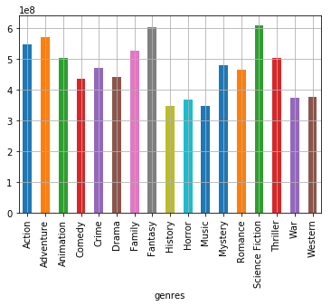

```python
# Grouping by genres names relative to profit to see which genre has the best average profit compared to the others
df_g.groupby('genres').profit.mean().plot(kind ='bar', grid = True);
```

### *In the top 250 movies, the genre is very effective in profitability as certain genres have higher chance of getting her profits. That is why ONLY Science Fiction and Fantasy got higher than 600 Million US Dollars (on average)*

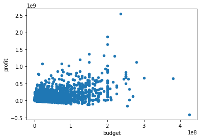

```python
df.plot(kind='scatter', x='budget', y='profit');
```

## Submitting your Project

```python
from subprocess import call
call(['python', '-m', 'nbconvert', 'Investigate_a_Dataset.ipynb'])
```

```
0
```